[← Volver a Día 2](https://valentinzarate.github.io/taller_mov/tema_2/tema2.html)

# Segmentación - MOM

# Modelos Ocultos de Markov

Hasta ahora trabajamos con métodos de segmentación como Lavielle y FPT, que identifican cambios en la estructura de la serie temporal Sin embargo, estos enfoques no modelan explícitamente un proceso subyacente que genere los datos. Los **Modelos Ocultos de Markov (HMM)** permiten asumir que el movimiento observado es generado por un proceso latente (oculto) que cambia en el tiempo, generando matrices de probabilidades que permiten predecir como los estados ocultos cambian en el tiempo y cómo estos se asocian con los estados observados.

En el contexto de ecología del movimiento, estos estados ocultos suelen interpretarse como *estados comportamentales* (por ejemplo: descanso, búsqueda, desplazamiento).

## Estados y números complejos

Siguiendo nuestro enfoque previo, representamos la trayectoria como una serie de números complejos:

$$Z_t = X_t + i Y_t$$

donde $X_t$ e $Y_t$ son las coordenadas UTM en el tiempo $t$.

A partir de esta representación derivamos dos variables clave, comúnmente usadas en los HMM.

**Longitud de paso (step length):**
$$|Z_t - Z_{t-1}|$$

**Ángulo de giro (turning angle):**
$$\arg\left(\frac{Z_t - Z_{t-1}}{Z_{t-1} - Z_{t-2}}\right)$$

Estas dos variables serán nuestras observaciones en el HMM. Lo más comun es que los HMM sean modelos bivariados, es decir que usan distribuciones de dos variables respuestas para generar sus predicciones. Los paquetes disponibles para estos modelos están diseñados para ajustar los modelos con las dos variables respuesta de arriba tratadas como independientes. sin embargo, es posible incorporar más variables e inclusive conectarlas entre sí, pero ahí tenemos que hacer nosotrs las funciones. Ejemplo de un HMM con 3 variables respuesta: [Barbour et al. 2023](https://conbio.onlinelibrary.wiley.com/doi/abs/10.1111/cobi.14114?__cf_chl_tk=KqEpVJR0It3isCkJoAa9DMOOids5VFcJGVqrC4BCcZ4-1777558445-1.0.1.1-Uq3tStiBqfGNa5FQmNYvFWfIfsGNxbDSgqAZhTsWYxc).

## Supuestos de los HMM

Un HMM asume que:

- Existe una secuencia de estados ocultos $S_t$ (no observables directamente).
- Los estados siguen una cadena de Markov.
- Las observaciones dependen del estado oculto actual, no de los anteriores
- Tanto estados como observaciones están separadas por **tiempos regulares**

De nuevo, existen mil variaciones de los HMM, estos son los clasicos y de primer orden (propiedad de Markov explícita).

En términos matemáticos sería así:

**Propiedad de Markov:**
$$P(S_t |
S_{t-1}, S_{t-2}, \dots) = P(S_t | S_{t-1})$$

**Distribución de observaciones:**
$$P(Z_t | S_t)$$

## Elementos del modelo

Un HMM está definido por tres componentes principales:

### Estados ocultos

Una variable discreta:

$$S_t \in \{1, 2, \dots, K\}$$

Cada estado representa un comportamiento (ej: forrajeo, desplazamiento).

### Matriz de transición

Describe la probabilidad de cambiar entre estados:

$$\Gamma = [\gamma_{ij}], \quad \gamma_{ij}
= P(S_t = j | S_{t-1} = i)$$

Cada fila suma 1.

### Matriz de emisión

Describen cómo se generan las observaciones dado el estado.

En nuestro caso:

- Step length: típicamente distribución Gamma o Weibull
- Turning angle: distribución von Mises

Entonces:

$$P(\text{step}_t, \text{angle}_t | S_t)$$

### Estructura completa del modelo

El modelo completo puede escribirse como:

$$P(S_1, \dots, S_T, Z_1, \dots, Z_T) =
P(S_1)\prod_{t=2}^{T} P(S_t | S_{t-1}) \prod_{t=1}^{T} P(Z_t | S_t)$$

### ¿Qué queremos estimar?

A partir de los datos observados (largo de pasos y ángulos), buscamos:

- Parámetros de las distribuciones (emisión)
- Matriz de transición
- Secuencia más probable de estados

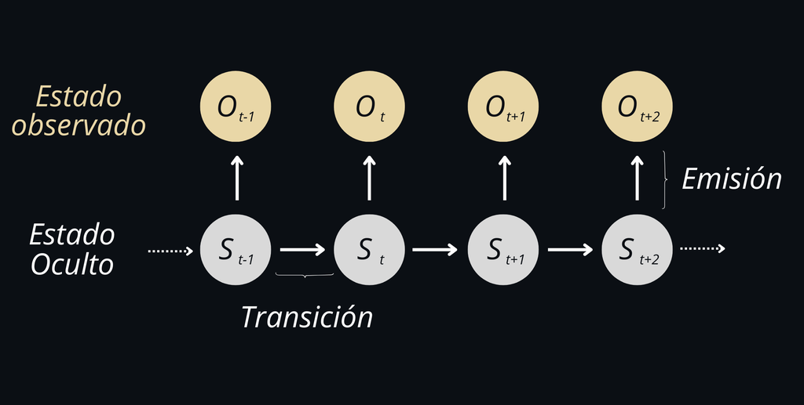

## Preparación de datos

Para arrancar vamos a hacer la misma trayectoria simulada de antes. La base de datos usada en los HMM, o al menos en el paquete que vamos a usar `momentuHMM` no pide mucho, y eso es tanto bueno como malo… Con coordendas UTM y un ID es suficiente, los modelos no inclñuyen la variable tiempo, así que tenemos que encargarnos que (1) tengamos fix rates regulares y (2) que las locs estén ordendas.

Nos vamos a quedar en lo básico, vamos a usar largo de pasos y ángulos de giro.. entonces los primeros pasos son tener nuestras UTM correctas (zona correcta) y luego estimar esas métricas… como ya hicimos antes, pero, vamos a ver que el `momentuHMM` tiene algunas exigencias.

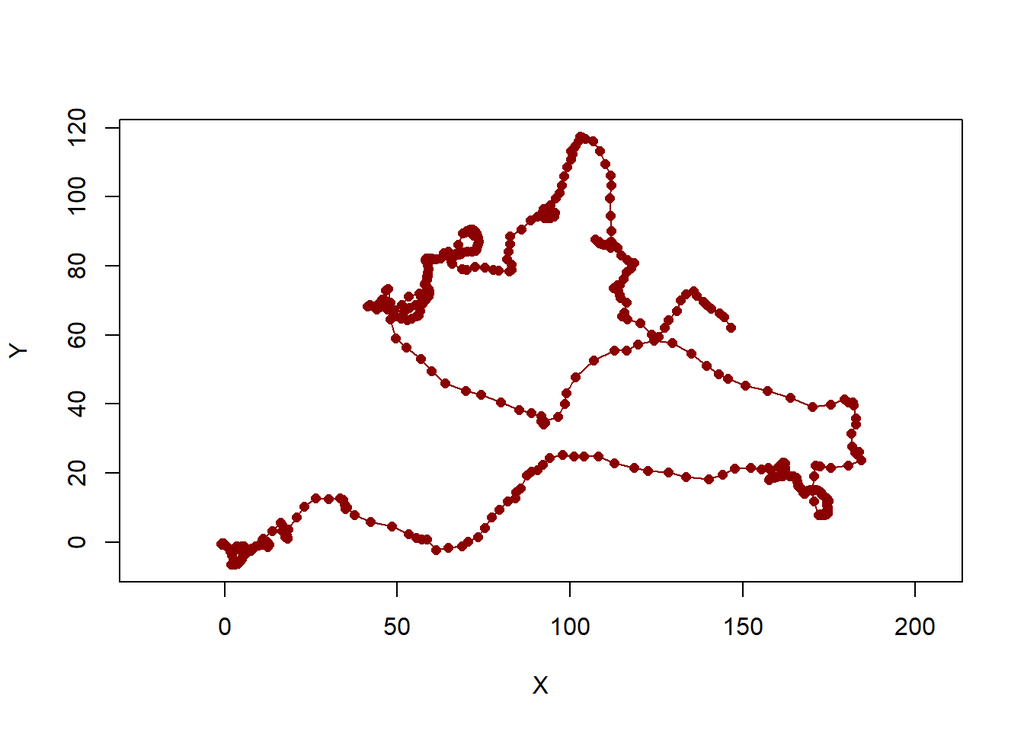

```r
set.seed(123)

n <- 500

segments <- list(
  list(n = 80,  sd = 0.3, drift = c(0,   0)),   # cluster 1
  list(n = 60,  sd = 1.2, drift = c(1.5, 0.5)), # tránsito
  list(n = 90,  sd = 0.25, drift = c(0,  0)),   # cluster 2
  list(n = 70,  sd = 1.5, drift = c(-1.2, 0.8)),# tránsito
  list(n = 100, sd = 0.35, drift = c(0,  0)),   # cluster 3
  list(n = 100, sd = 1.0, drift = c(0.8, -0.6)) # tránsito final
)

X <- c()
Y <- c()

x0 <- 0
y0 <- 0

for(seg in segments){

  dx <- arima.sim(n = seg$n, model = list(ar = 0.8), sd = seg$sd) + seg$drift[1]
  dy <- arima.sim(n = seg$n, model = list(ar = 0.8), sd = seg$sd) + seg$drift[2]

  x <- x0 + cumsum(dx)
  y <- y0 + cumsum(dy)

  X <- c(X, x)
  Y <- c(Y, y)

  x0 <- tail(x, 1)
  y0 <- tail(y, 1)}

Z <- X + 1i * Y

n <- length(Z)

start <- as.POSIXct("2024-01-01 00:00:00", format = "%Y-%m-%d %H:%M:%S")

t <- seq(from = start,
         by = "60 mins",
         length.out = n)

df <- data.frame(
  X = X,
  Y = Y,
  Z = Z,
  t = t)

plot(df$Z,
     type = "o",
     asp = 1,
     pch = 16,
     cex = 0.9,
     col = "darkred",
     xlab = "X",
     ylab = "Y")
```

## Step length y turning angle

A partir de la trayectoria compleja:

$$Z_t = X_t + iY_t$$

podemos obtener los desplazamientos entre posiciones sucesivas como:

$$\Delta Z_t = Z_t - Z_{t-1}$$

La **longitud de paso** se obtiene con el módulo:

$$SL_t = |\Delta Z_t|$$

y el **ángulo de giro** como el argumento del cambio relativo entre dos desplazamientos consecutivos:

$$TA_t = Arg\left(\frac{\Delta Z_t}{\Delta
Z_{t-1}}\right)$$

```r
dZ <- diff(df$Z)

SL <- Mod(dZ)

TA <- Arg(dZ[-1] / dZ[-length(dZ)])

SL <- SL[-1]

mov <- data.frame(
  t = df$t[-c(1, 2)],
  X = df$X[-c(1, 2)],
  Y = df$Y[-c(1, 2)],
  Z = df$Z[-c(1, 2)],
  SL = SL,
  TA = TA)
```

Nada nuevo por el momento

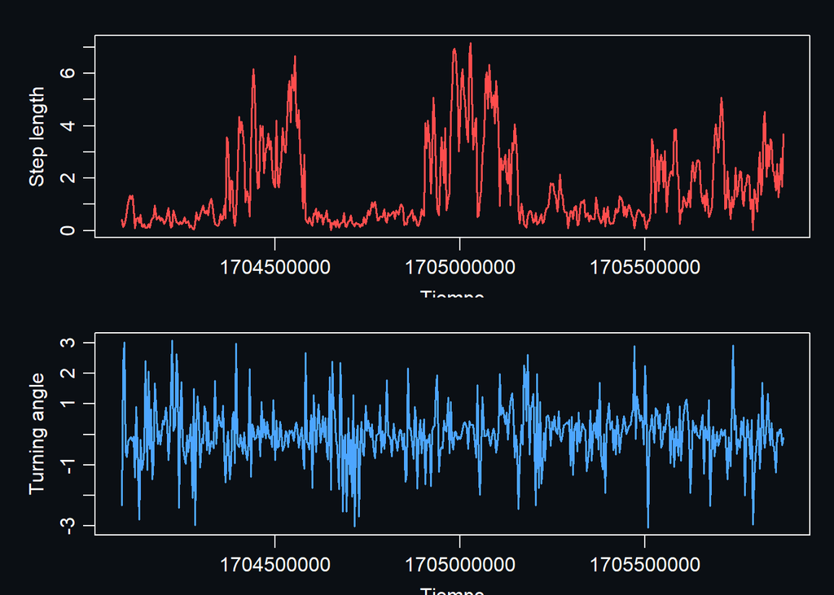

```r
par(mfrow = c(2, 1),
    mar = c(2.5, 4, 1.5, 1),
    mgp = c(2, 0.7, 0),
    bg = "#0b0f14",
    col.axis = "white",
    col.lab = "white")

# Plot 1
plot(mov$t, mov$SL,
     type = "l",
     col = "#ff4d4d",
     lwd = 1.5,
     xlab = "Tiempo",
     ylab = "Step length",
     axes = FALSE)

axis(1, col = "white", col.axis = "white")
axis(2, col = "white", col.axis = "white")
box(col = "white")

# Plot 2
plot(mov$t, mov$TA,
     type = "l",
     col = "#4da6ff",
     lwd = 1.5,
     xlab = "Tiempo",
     ylab = "Turning angle",
     axes = FALSE)

axis(1, col = "white", col.axis = "white")
axis(2, col = "white", col.axis = "white")
box(col = "white")
```

```r
par(mfrow = c(1, 1))
```

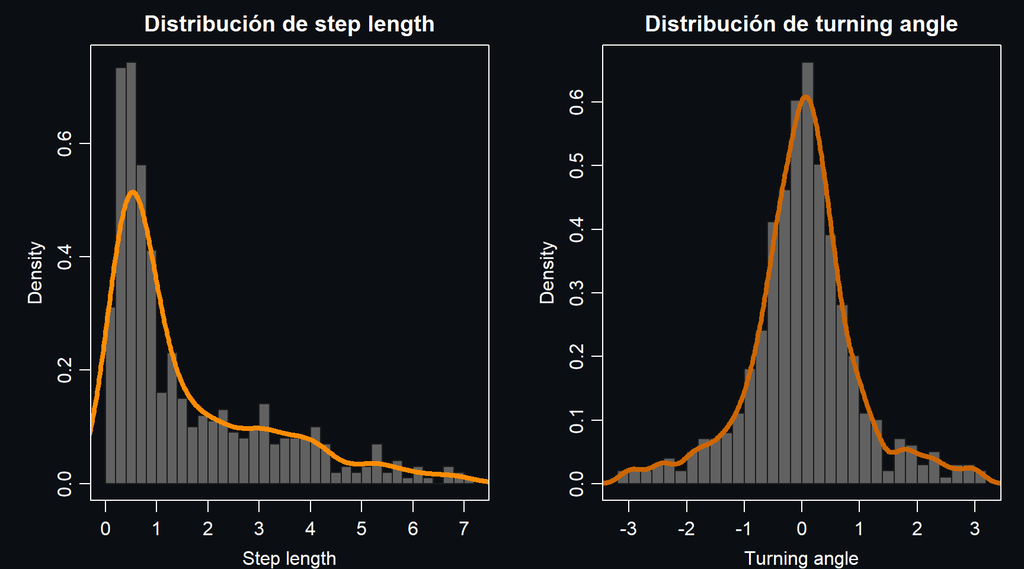

```r
par(mfrow = c(1, 2),
    mar = c(3, 4, 2, 1),
    mgp = c(2, 0.7, 0),
    bg = "#0b0f14",
    col.axis = "white",
    col.lab = "white",
    col.main = "white")

# Histograma SL
hist(mov$SL,
     breaks = 30,
     col = "grey38",        # gris oscuro
     border = "grey11",
     main = "Distribución de step length",
     xlab = "Step length",
     freq = FALSE,
     axes = FALSE)

lines(density(mov$SL),
      col = "darkorange",
      lwd = 4)

axis(1, col = "white", col.axis = "white")
axis(2, col = "white", col.axis = "white")
box(col = "white")

# Histograma TA
hist(mov$TA,
     breaks = 30,
     col = "grey38",
     border = "grey11",
     main = "Distribución de turning angle",
     xlab = "Turning angle",
     freq = FALSE,
     axes = FALSE)

lines(density(mov$TA),
      col = "darkorange3",
      lwd = 4)

axis(1, col = "white", col.axis = "white")
axis(2, col = "white", col.axis = "white")
box(col = "white")
```

```r
par(mfrow = c(1, 1))
```

Como vamos a ver después esto tiene bastante sentido con una “trayectoria real”, muchos angulos de giro concentrados en cero y muchos pasos cortos y pocos largos.

## momentuHMM

Vamos a tener que usar este paquete.. la versión anterior “moveHMM” es muy parecida, pero acá le mejoraron una función interesante que se llama `plotStationary()`, aunque en realidad no la vamos a usar (vamos a usar otra casera). Si ponene `vignette(“momentuHMM”)` pueden pispiar la descripción del paquete.

El paquete tiene algunas restricciones respecto a los nombres… los que acepta son los de abajo (para covariables es más flexible, pero vamos por partes).

```r
library(momentuHMM)
library(dplyr)

data_raw <-
  data.frame(
  ID = "animal_1",
  x = df$X,
  y = df$Y,
  t = df$t)

head(data_raw)
```

|  | ID | x | y | t |
| --- | --- | --- | --- | --- |
| 1 | animal_1 | -0.7031439 | -0.5171118 | 2024-01-01 00:00:00 |
| 2 | animal_1 | -0.8895145 | -0.7088170 | 2024-01-01 01:00:00 |
| 3 | animal_1 | -0.9106717 | -0.2894501 | 2024-01-01 02:00:00 |
| 4 | animal_1 | -1.0161189 | -0.3871246 | 2024-01-01 03:00:00 |
| 5 | animal_1 | -0.8319390 | -0.2547288 | 2024-01-01 04:00:00 |
| 6 | animal_1 | -0.4211550 | -0.2274714 | 2024-01-01 05:00:00 |

Aca usamos `prepData` para crear el objeto necesario para ajustar el modelo oculto de markov. Verán que es un tipo de objeto data.frame “especial”. Esto es importante porque las próximas funicones del paquete solo aceptan estos tipos de objetos, lo cual te limita bastante.

```r
data_hmm <- prepData(
  data = data_raw,
  type = "UTM",
  coordNames = c("x", "y"))

class(data_hmm)
```

```
## [1] "momentuHMMData" "data.frame"
```

Verán que no es nada raro.. de hecho es una df muy similar a la que hemos calculado antes.

```r
head(data_hmm)
```

|  | ID | step | angle | t | x | y |
| --- | --- | --- | --- | --- | --- | --- |
| 1 | animal_1 | 0.2673666 | NA | 2024-01-01 00:00:00 | -0.7031439 | -0.5171118 |
| 2 | animal_1 | 0.4199003 | -2.3198958 | 2024-01-01 01:00:00 | -0.8895145 | -0.7088170 |
| 3 | animal_1 | 0.1437338 | 2.2675388 | 2024-01-01 02:00:00 | -0.9106717 | -0.2894501 |
| 4 | animal_1 | 0.2268279 | 3.0177007 | 2024-01-01 03:00:00 | -1.0161189 | -0.3871246 |
| 5 | animal_1 | 0.4116873 | -0.5570008 | 2024-01-01 04:00:00 | -0.8319390 | -0.2547288 |
| 6 | animal_1 | 0.7301338 | -0.7300424 | 2024-01-01 05:00:00 | -0.4211550 | -0.2274714 |

Inclusive podemos revertir esto muy fácilmente, lo cual es bastante bueno… aunque “data” ahora no es aceptada por las funciones del paquete, a pesar de ser estrucutralmente idéntica 😤

```r
data <- as.data.frame(data_hmm)
```

Inclusive, podemos usar los números complejos para crear estas mismas columnas.. solo le hace mínimos ajustes.

```r
data$Z <- data$x + 1i * data$y

data <- data |>
  group_by(ID)  |>
  mutate(
    Z = x + 1i * y,

    step_manual = c(Mod(diff(Z)), NA_real_),

    heading_manual = c(Arg(diff(Z)), NA_real_),

    angle_manual = c(
      NA_real_,
      atan2(
        sin(diff(Arg(diff(Z)))),
        cos(diff(Arg(diff(Z))))),
      NA_real_)) |>
  ungroup()
```

La unica diferencia real que hay acá es que **momentuHMM** lo lleva a radianes que entre [$-\pi$,$\pi$]. Esto sirve para modelar luego con Von Mises y otras distribuciones como Wrapped Cauchy (permite muchos giros chiquitos). Pero bueno haciendo eso de arco tangente y seno y coseno lo resolvemos…

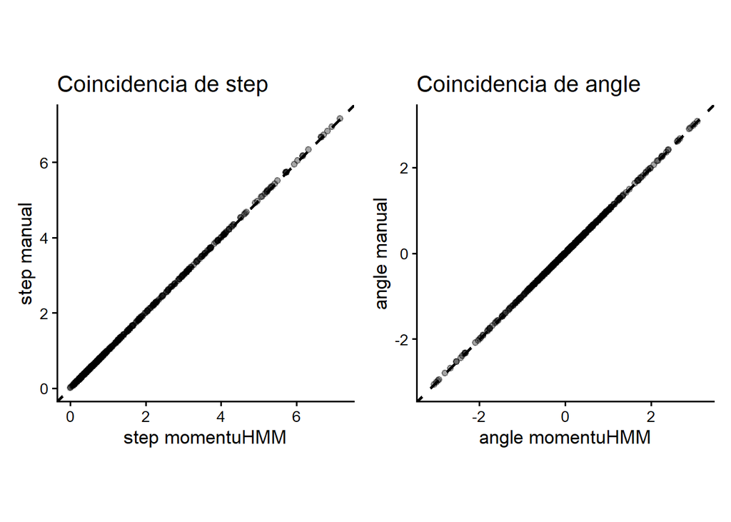

```r
library(ggplot2)
library(dplyr)
library(patchwork)

data_hmm_df <- as.data.frame(data_hmm)

check_df <- data_hmm_df |>
  mutate(
    step_manual = data$step_manual,
    angle_manual = data$angle_manual)

p_step <- ggplot(check_df, aes(x = step, y = step_manual)) +
  geom_point(alpha = 0.35, size = 1.8) +
  geom_abline(slope = 1, intercept = 0, linewidth = 1, linetype = "dashed") +
  coord_equal() +
  labs(
    x = "step momentuHMM",
    y = "step manual",
    title = "Coincidencia de step") +
  theme_classic(base_size = 13)

p_angle <- ggplot(check_df, aes(x = angle, y = angle_manual)) +
  geom_point(alpha = 0.35, size = 1.8) +
  geom_abline(slope = 1, intercept = 0, linewidth = 1, linetype = "dashed") +
  coord_equal(xlim = c(-pi, pi), ylim = c(-pi, pi)) +
  labs(
    x = "angle momentuHMM",
    y = "angle manual",
    title = "Coincidencia de angle") +
  theme_classic(base_size = 13)

p_step + p_angle
```

```r
head(data_hmm)
```

|  | ID | step | angle | t | x | y |
| --- | --- | --- | --- | --- | --- | --- |
| 1 | animal_1 | 0.2673666 | NA | 2024-01-01 00:00:00 | -0.7031439 | -0.5171118 |
| 2 | animal_1 | 0.4199003 | -2.3198958 | 2024-01-01 01:00:00 | -0.8895145 | -0.7088170 |
| 3 | animal_1 | 0.1437338 | 2.2675388 | 2024-01-01 02:00:00 | -0.9106717 | -0.2894501 |
| 4 | animal_1 | 0.2268279 | 3.0177007 | 2024-01-01 03:00:00 | -1.0161189 | -0.3871246 |
| 5 | animal_1 | 0.4116873 | -0.5570008 | 2024-01-01 04:00:00 | -0.8319390 | -0.2547288 |
| 6 | animal_1 | 0.7301338 | -0.7300424 | 2024-01-01 05:00:00 | -0.4211550 | -0.2274714 |

## Ajustar HMM

Bien, ahora vamos a ajustar un HMM. Lo primero es asegurarnos que el tiempo esten organizados de menor a mayor (y dentro de cada individuo en el caso de tener más de 1)

```r
data_hmm <- data_hmm |>
  group_by(ID) |>
  arrange(t)
```

Primero asignamos cuantos estados queremos.. dos es un número razonable, tres también.. cuatro ya es medio raro y cinco rarisimo. Lo importante es tener muy en claro que estados biológicos podemos llegar a diferenciar solo valiendonos de largo de pasos y angulos de giro… un estado residente vs uno de tránsito debería ser fácil… distinguir tránsito lento y tránsito rápido también, pero de ahí se empieza a complicar.

```r
nbStates <- 2
```

Valores iniciales

En un HMM ajustado con *momentuHMM*, el algoritmo *forward algorithm* calcula la verosimilitud para un conjunto dado de parámetros, es decir:

$$L(\theta \mid datos)$$

donde $\theta$ incluye parámetros de *step length*, *turning angle* y probabilidades de transición. Ese valor se lo pasa a un optimizador como BFGS, que sí intenta encontrar el máximo de la verosimilitud. Para eso, BFGS usa el gradiente (primera derivada; hill climbing)
$$\nabla
\log L(\theta)$$
para determinar hacia dónde aumenta la función, y además construye una aproximación de la curvatura (segunda derivada) para mejorar la dirección de búsqueda.

Esto que significa que no solo “sube la pendiente”, sino que también tiene en cuenta la forma del paisaje de la verosimilitud. Sin embargo, como en los HMM la función de verosimilitud suele tener varios picos (máximos locales), el optimizador es local y depende fuertemente de los *starting values*
$$\theta_0$$

Si arrancamos cerca de un máximo local, el algoritmo va a converger a ese punto y no necesariamente al máximo global, aunque exista uno mejor en otra región del espacio de parámetros. Por eso, elegir buenos valores iniciales o correr el modelo varias veces desde distintos puntos p´pede ayudar a evitar soluciones subóptimas. Ahora no vamos a hacer eso porqe es un viaje, pero para tenerlo en cuenta cuando se aplique seriamente.

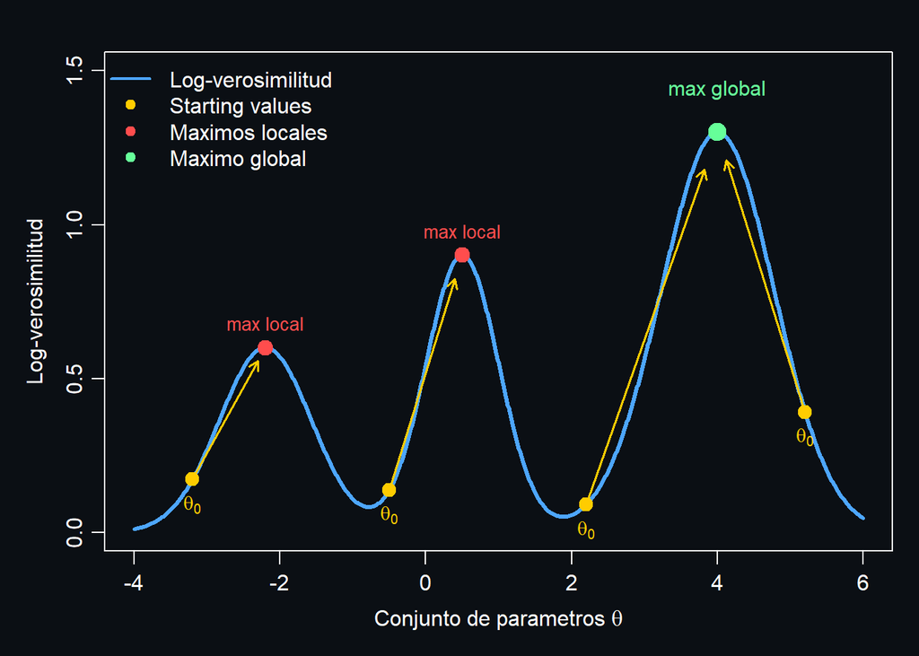

Más simple de lo que parece.. podemos arrancar con estos valores iniciales.. definimos medias y SD para pasos.. y para angulos solo un parametro $k$ de concetración.. más alto más persistente la direccion. En este caso estamos diciendo que pensamos que el animal puede exhibir dos estados.. un estado mas lerdo con un largo de pasos de 1 y una concentracion baja (mucho cambio de dirección) y un estado dos más rápido y direccional, con largo de pasos 3 y poco cambio de dirección.

```r
Par0 <- list(
  step = c(
    1, 3,   # medias iniciales de step
    0.3, 3),  # sd iniciales de step
  angle = c(
    0.2, 1)) # concentraciones iniciales de angle
```

Las distribuciones de los datos.. *steps* van a ser Gamma porque son valores continuos y positivos, posiblemente amontonados en valores pequeños.. los angulos le vamos a poner Von Mises.. también podría ser Wrapped Cauchy.

```r
dist <- list(
  step = "gamma",
  angle = "vm")
```

### fitHMM

Acá ajustamos el modelo, tenemos que definirle las cosas que mencionamos antes.

```r
mod <- fitHMM(
  data = data_hmm,
  nbStates = nbStates,
  dist = dist,
  Par0 = Par0)
```

momentuHMM tira unos plots medio fieros a mi criterio, pero son informativos. Ya vamos a ver cómo extraer la info para poder hacer plots más personalizados.

```
## Decoding state sequence... DONE
```

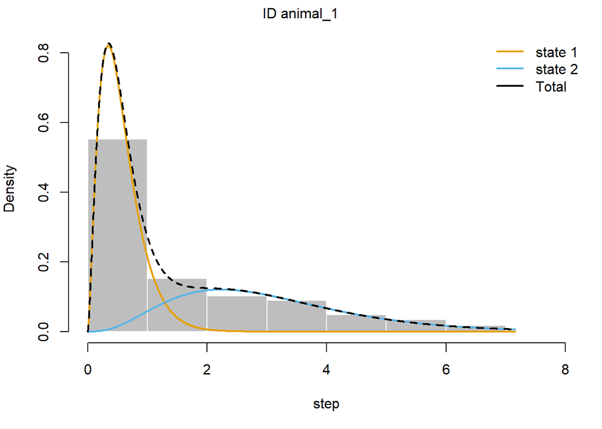

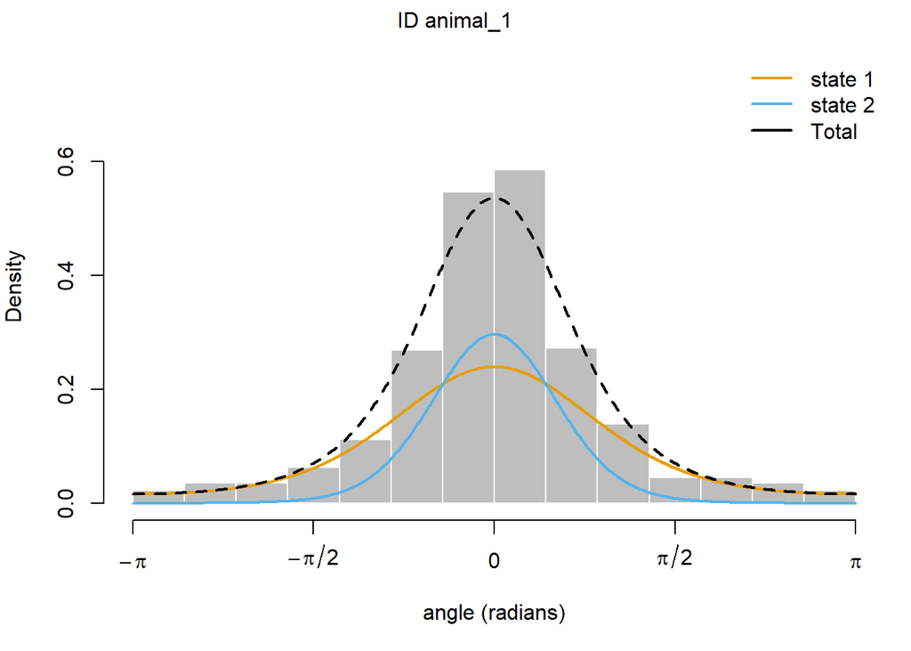

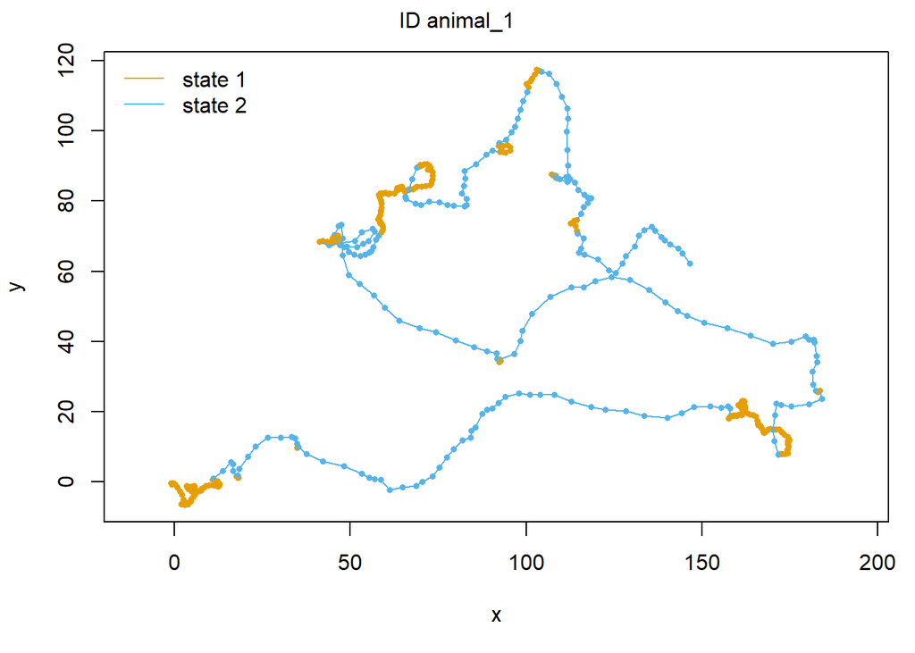

```r
plot(mod)
```

Resumen del modelo

```r
mod
```

```
## Value of the maximum log-likelihood: -1123.712
##
##
## step parameters:
## ----------------
##        state 1  state 2
## mean 0.5579407 3.019322
## sd   0.3462168 1.541093
##
## angle parameters:
## -----------------
##                state 1  state 2
## mean          0.000000 0.000000
## concentration 1.355354 3.548515
##
## Regression coeffs for the transition probabilities:
## ---------------------------------------------------
##                1 -> 2    2 -> 1
## (Intercept) -3.115324 -2.843651
##
## Transition probability matrix:
## ------------------------------
##            state 1    state 2
## state 1 0.95752042 0.04247958
## state 2 0.05501045 0.94498955
##
## Initial distribution:
## ---------------------
##      state 1      state 2
## 9.999880e-01 1.198336e-05
```

Ya vamos a charlar de toods los elementos.. pero los más obvios son los paramtros estimados para cada estado..ponele, nos dice que el estado 1 tiene pasos de 0.55 y el dos de 3… bastante razonable.. despúes tenemos probabilidad de transicion..Las proabilidades de emision no estan explicitamente puestasm sino que se calcular a traves de los parámetros estimados con la likelihood. $P(SL_t, TA_t \mid S_t = k)$

Arriba de todo vemos “*Value of the maximum log-likelihood: -1123.712*”, este es el máximo encontrado por el optimizador BFGS dados nuestros valores iniciales.. tras muchas corridas con distintos iniciales podríamos (o no) encontrar distintos valores.. mientras más cercano a cero mejor… Hay que tener en cuenta que lo que importa es la comparación, no el valor en sí.

### Viterbi

Sobre el modelo ajustado podemos aplicar el algoritmo **Viterbi**. Este algoritmo necesita las matrices y los paramétros, o sea que no ajusta nada en sí… lo que hace es estimar la secuencia más probables de estados ocultos para los datos observados, dadas las probabilidad de transición y emisión

```r
states <- viterbi(mod)
data_hmm$state <- states
df$state <- NA
```

Viterbi te da un vector de numeritos entre 1 y 2.. lo que podemos hacer es unirlo a la df original y chau

```r
df$state <- data_hmm$state
```

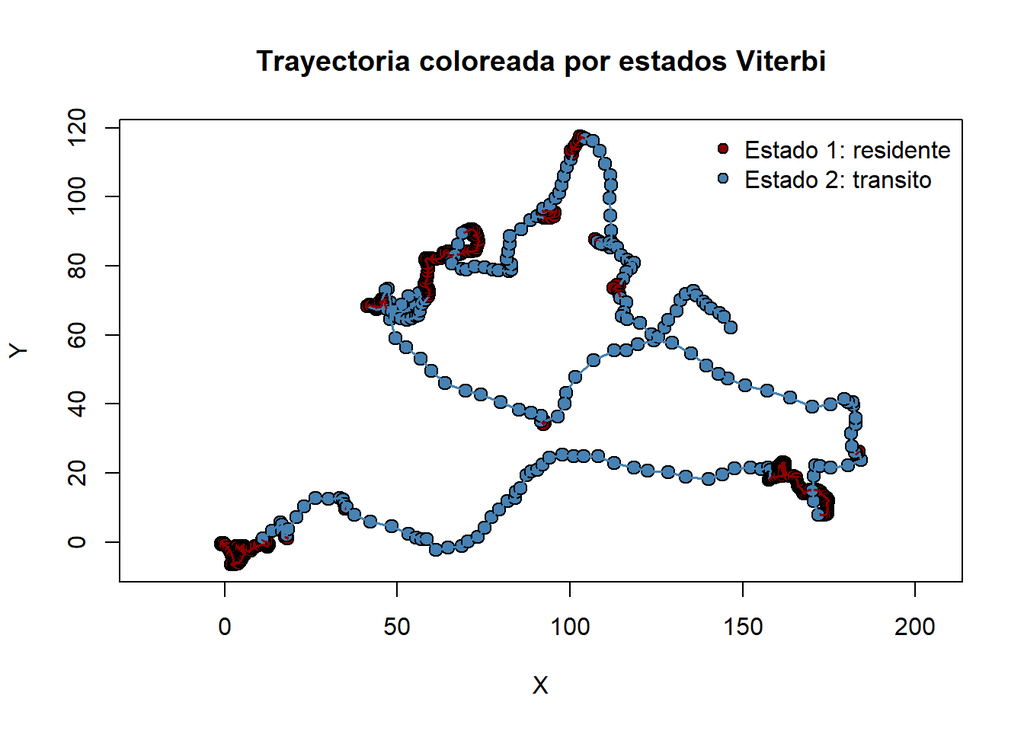

```r
cols <- c("darkred", "steelblue")

plot(df$X, df$Y,
     bg = cols[df$state],
     col = "black",
     pch = 21,
     cex = 1.23,
     asp = 1,
     xlab = "X",
     ylab = "Y",
     main = "Trayectoria coloreada por estados Viterbi")

for (i in 1:(nrow(df) - 1)) {
  segments(df$X[i], df$Y[i],
           df$X[i+1], df$Y[i+1],
           col = cols[df$state[i]],
           lwd = 1.5)
}

legend("topright",
       legend = c("Estado 1: residente", "Estado 2: transito"),
       pt.bg = cols,
       col = "black",
       pch = 21,
       bty = "n")
```

Metemos todo el na df original y tenemos para análizar lo que querramos.

```r
df$step <- data_hmm$step
df$angle <- data_hmm$angle
df$state <- data_hmm$state
```

### Distribuciones por estado

Una forma muy clara de interpretar el modelo es ver cómo cambian las distribuciones de las variables observadas entre estados:

$$P(SL_t \mid S_t = k), \quad P(TA_t \mid
S_t = k)$$

Esto nos permite verificar si los estados realmente capturan distintos modos de movimiento.

**Histogramas de step length por estado**

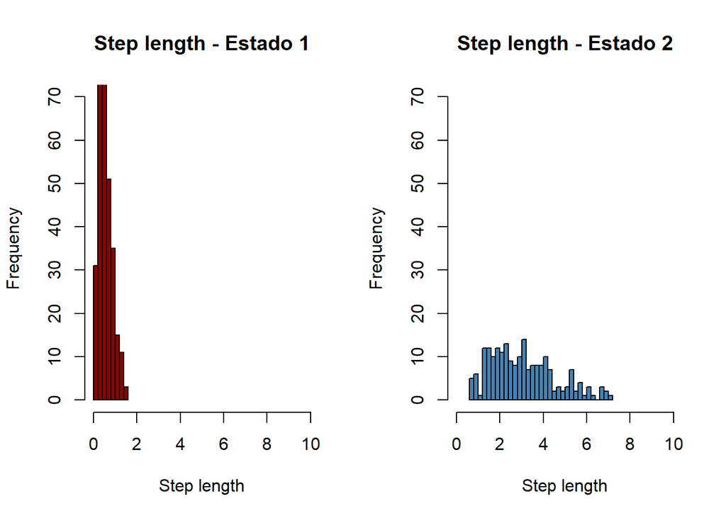

```r
par(mfrow = c(1, 2))

hist(df$step[df$state == 1],
     breaks = 10,
     col = "darkred",
     border = "black",
     main = "Step length - Estado 1",
     xlab = "Step length",
     xlim = c(0,10),
     ylim = c(0, 70))

hist(df$step[df$state == 2],
     breaks = 30,
     col = "steelblue",
     border = "black",
     main = "Step length - Estado 2",
     xlab = "Step length",
          xlim = c(0,10),
     ylim = c(0, 70))
```

```r
par(mfrow = c(1, 1))
```

```r
library(circular)

angle_circ <- circular(df$angle,
                       type = "angles",
                       units = "radians",
                       template = "geographics")


angle_circ_1 <- angle_circ[df$state == 1]
angle_circ_2 <- angle_circ[df$state == 2]
```

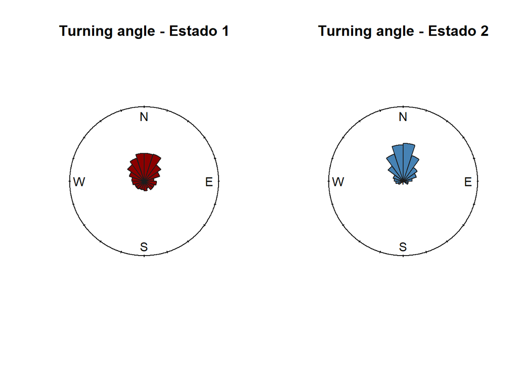

```r
par(mfrow = c(1, 2))

rose.diag(angle_circ_1,
          bins = 20,
          col = "darkred",
          border = "grey11",
          ylim = c(0, 0.1),
          main = "Turning angle - Estado 1")

rose.diag(angle_circ_2,
          bins = 20,
          col = "steelblue",
          border = "grey11",
          ylim = c(0, 0.1),
          main = "Turning angle - Estado 2")
```

```r
par(mfrow = c(1, 1))
```

## HMM en la teoría

En el ejemplo de la traycetoria simulada extrajimos dos métrricas de resumen clave.. el largo de los pasos y los ángulos de giro.. podría ser otra si quisiesemos, la lógica es la misma.

$$Y_t = (SL_t, TA_t)$$

En mnuestro caso $SL_t$ es la longitud de paso y $TA_t$ es el ángulo de giro. Estas variables son observadas y asumimos que operan independientemente. Lo que no observamos directamente es el estado comportamental que generó cada conjunto de observaciones.

El estado latente u oculto $ S_t {1, 2} $ va a representar una categoria subyacente que terminará generando a $SL_t$ y $TA_t$.

En nuestro modelo ajustado, esos estados terminaron representando aproximadamente:

- **Estado 1:** movimiento restringido, con pasos cortos.
- **Estado 2:** tránsito, con pasos largos y mayor persistencia direccional.

Un HMM está definido por tres componentes principales.

La distribución inicial indica la probabilidad de comenzar en cada estado:

$$\delta_k = P(S_1 = k)$$

Esto indica que la trayectoria comienza casi con seguro en el estado 1, lo cual coincide con la simulación… el primer segmento era un cluster.

La matriz de transición describe la probabilidad de pasar de un estado a otro:

$$\Gamma =
\begin{pmatrix}
\gamma_{11} & \gamma_{12} \\
\gamma_{21} & \gamma_{22}
\end{pmatrix}$$

donde:

$$\gamma_{ij} = P(S_t = j \mid S_{t-1} = i)$$

En el modelo…

$$\Gamma =
\begin{pmatrix}
0.9575 & 0.0425 \\
0.0550 & 0.9450
\end{pmatrix}$$

Esto significa que ambos estados son persistentes… si el animal está en un estado, tiene alta probabilidad de permanecer en ese mismo estado en el siguiente paso.Ecolgiocamente esto es importante, podemos ver tendencias de comportamientos en el espacio y tiempo.. comparar si esto cambia para la misma especie en otro ambiente puede dar información importante.

Las emisiones describen cómo se generan las observaciones dado el estado oculto:

$$P(Y_t \mid S_t = k)$$

Como nuestras observaciones son:

$$Y_t = (SL_t, TA_t)$$

modelamos:

$$P(Y_t \mid S_t = k)
=
P(SL_t \mid S_t = k)\;P(TA_t \mid S_t = k)$$

En este caso usamos:

$$SL_t \mid S_t = k \sim Gamma(\mu_k, \sigma_k)$$

y:

$$TA_t \mid S_t = k \sim vonMises(0, \kappa_k)$$

Los parámetros estimados fueron:

$$\mu_1 = 0.558,\quad \sigma_1 = 0.346$$

$$\mu_2 = 3.019,\quad \sigma_2 = 1.541$$

para los step lengths, y:

$$\kappa_1 = 1.355,\quad \kappa_2 = 3.549$$

para los turning angles.

### La verosimilitud del HMM

El objetivo del ajuste es encontrar los parámetros del modelo que hacen más probables los datos observados.

Llamemos:

$$\theta = \{\delta, \Gamma, \mu_k, \sigma_k, \kappa_k\}$$

El objetivo es maximizar:

$$L(\theta) = P(Y_1, Y_2, \dots, Y_T \mid \theta)$$

o, más comúnmente, su logaritmo:

$$\ell(\theta) = \log P(Y_1, Y_2, \dots, Y_T \mid \theta)$$

En nuestro ajuste, el valor máximo encontrado fue:

$$\ell(\hat{\theta}) = -1123.712$$

### El problema: los estados “nunca” se observan

Si conociéramos la secuencia completa de estados:

$$S_1, S_2, \dots, S_T$$

sería relativamente directo calcular la probabilidad conjunta:

$$P(Y_{1:T}, S_{1:T})
=
P(S_1)
\prod_{t=2}^{T} P(S_t \mid S_{t-1})
\prod_{t=1}^{T} P(Y_t \mid S_t)$$

Pero los estados son ocultos. Entonces la verosimilitud observada requiere sumar sobre todas las posibles secuencias de estados:

$$P(Y_{1:T})
=
\sum_{S_1}\sum_{S_2}\cdots\sum_{S_T}
P(Y_{1:T}, S_{1:T})$$

Si hay $K$ estados y $T$ observaciones, existen:

$$K^T$$

secuencias posibles. Por eso no podemos calcular esta suma de forma ingenua.

### El algoritmo forward

El algoritmo **forward** permite calcular eficientemente la verosimilitud sin enumerar todas las secuencias posibles de estados.

Define una cantidad recursiva:

$$\alpha_t(j)
=
P(Y_1, Y_2, \dots, Y_t,\; S_t = j)$$

Es decir, $\alpha_t(j)$ es la probabilidad de haber observado los datos hasta el tiempo $t$ y estar en el estado $j$ en ese tiempo.

#### Inicialización

Para el primer tiempo:

$$\alpha_1(j)
=
\delta_j \; f_j(Y_1)$$

donde $f_j(Y_1)$ es la densidad de emisión del estado $j$ evaluada en la observación $Y_1$.

#### Recursión

Para cada tiempo posterior:

$$\alpha_t(j)
=
f_j(Y_t)
\sum_{i=1}^{K}
\alpha_{t-1}(i)\gamma_{ij}$$

Esta expresión tiene dos partes:

- la suma acumula todas las formas posibles de llegar al estado $j$ desde los estados previos;
- la densidad $f_j(Y_t)$ mide qué tan probable es la observación actual bajo el estado $j$.

#### Verosimilitud final

Al final de la serie:

$$P(Y_{1:T})
=
\sum_{j=1}^{K}
\alpha_T(j)$$

Así obtenemos la verosimilitud de los datos observados.

### Optimización por máxima verosimilitud

El paquete `momentuHMM` usa este cálculo de la verosimilitud para buscar los parámetros que maximizan:

$$\hat{\theta}
=
\arg\max_{\theta}
\log P(Y_{1:T} \mid \theta)$$

En otras palabras, prueba distintos valores de los parámetros, calcula la verosimilitud mediante el algoritmo forward, y se queda con el conjunto de parámetros que produce la mayor verosimilitud.

El ajuste del HMM, por lo tanto, no consiste en asignar estados directamente, sino en estimar:

- la matriz de transición $\Gamma$;
- los parámetros de las distribuciones de emisión;
- la distribución inicial $\delta$.

Una vez estimados los parámetros:

$$\hat{\theta}
=
\{\hat{\delta}, \hat{\Gamma}, \hat{f}_1, \hat{f}_2\}$$

podemos preguntarnos:

¿Cuál es la secuencia de estados más probable que generó estos datos?

Esa pregunta la responde el algoritmo de **Viterbi**.

Viterbi busca:

$$\hat{S}_{1:T}
=
\arg\max_{S_{1:T}}
P(S_{1:T} \mid Y_{1:T}, \hat{\theta})$$

Es decir, toma los parámetros ya estimados y encuentra el camino de estados ocultos más probable.

### El algoritmo de Viterbi

Viterbi también es recursivo, pero a diferencia del algoritmo forward no suma sobre todos los caminos posibles. En cambio, conserva solo el camino más probable.

Define:

$$v_t(j)
=
\max_{S_1,\dots,S_{t-1}}
P(S_1,\dots,S_{t-1}, S_t=j, Y_1,\dots,Y_t)$$

Es decir, $v_t(j)$ es la probabilidad del camino más probable que termina en el estado $j$ en el tiempo $t$.

#### Inicialización

$$v_1(j)
=
\hat{\delta}_j f_j(Y_1)$$

#### Recursión

$$v_t(j)
=
f_j(Y_t)
\max_i
\left[
v_{t-1}(i)\hat{\gamma}_{ij}
\right]$$

La diferencia clave con forward es:

Forward suma:

$$\sum_i \alpha_{t-1}(i)\gamma_{ij}$$

Viterbi maximiza:

$$\max_i \left[v_{t-1}(i)\gamma_{ij}\right]$$

### Reconstrucción del camino

Además de calcular probabilidades, Viterbi guarda desde qué estado anterior vino el máximo. A esos registros se los suele llamar *backpointers*.

Al llegar al final de la serie, el algoritmo identifica el estado final más probable y reconstruye hacia atrás toda la secuencia:

$$\hat{S}_T,\hat{S}_{T-1},\dots,\hat{S}_1$$

## Diferencia entre forward y Viterbi

| Algoritmo | Pregunta que responde | Operación clave | Uso |
| --- | --- | --- | --- |
| Forward | ¿Qué tan probables son los datos bajo este modelo? | Suma sobre caminos | Ajustar el modelo por máxima verosimilitud |
| Viterbi | ¿Cuál es el camino de estados más probable? | Máximo sobre caminos | Clasificar cada observación en un estado |

Entonces, desarmando lo que hicimos en la trayectoria simulada… primero ajustamos el modelo, estimando que:

- el estado 1 tiene pasos cortos: $\mu_1 = 0.558$;
- el estado 2 tiene pasos largos: $\mu_2 = 3.019$;
- el estado 2 tiene mayor concentración angular: $\kappa_2 = 3.549$;
- ambos estados son persistentes, porque $\gamma_{11}$ y $\gamma_{22}$ son altos.

Luego Viterbi usa esos parámetros para decidir, en cada punto de la trayectoria, qué estado es más probable.

Por ejemplo, una observación con:

- step corto;
- ángulo relativamente variable;
- ubicada dentro de una secuencia persistente de pasos cortos;

tendrá alta probabilidad de ser asignada al estado 1.

En cambio, una observación con:

- step largo;
- ángulo cercano a cero;
- ubicada dentro de una secuencia persistente de desplazamiento;

tendrá alta probabilidad de ser asignada al estado 2.

El HMM se ajusta en dos etapas conceptuales:

Primero, estimamos los parámetros del proceso generador:

$$Y_t = (SL_t, TA_t)
\quad \longrightarrow \quad
\hat{\theta}$$

Esto se hace por máxima verosimilitud usando el algoritmo forward.

Segundo, usamos esos parámetros estimados para reconstruir la secuencia oculta:

$$\hat{\theta}, Y_{1:T}
\quad \longrightarrow \quad
\hat{S}_{1:T}$$

Esto se hace con el algoritmo de Viterbi.

Por eso Viterbi no “fitea” el HMM. Viterbi usa el HMM ya ajustado para descomponer la trayectoria en una secuencia de estados comportamentales.

## Covariables

Algo clave en ecología es poder modelar cómo cambian estas matrices de emisión y transición en función de variables explicativas, lo que consecuentemente tendrá impacto en la secuencia estimada por Viterbi.

momentuHMM avanzó bastante en eso y permitió estimar las probabilidad estacionarias de cada estado dada una serie de covariables.. con una sintaxis bastante similar a la usada en GLMs. Sin embargo, es bastante inmanejable, pero más abajo pongo una funcón que permite generar una df ccon estas proabilidades.

Vamos a armar un raster de NDVI para ver cómo funcionaría todo.. Después lo vamos a ver con datos posta.

Con este raster tenemos lo básico para estimar cosas interesantes.. el raster está armado en función de la trayectoria así que es esperable que de algo muy fuerte.

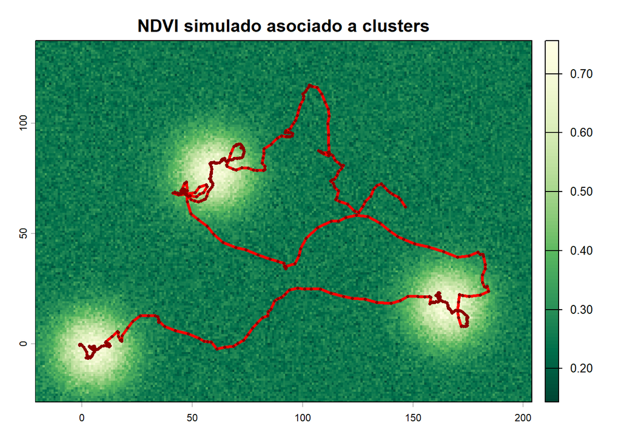

```r
plot(r,
     main = "NDVI simulado asociado a clusters",
     col = hcl.colors(100, "YlGn"))

lines(df$X, df$Y,
      col = "red",
      lwd = 3)

points(df$X, df$Y,
       pch = 16,
       cex = 0.5,
       col =  "darkred")
```

Acá compatibilizamos df a raster.. podríamos haber usado st_as_sf de “sf” pero bueno, seguimos con terra.. en el ejemplo posta vamos a usar SF porque me resulta más intuitivo.

con `terra::extract` sacamos las covariables de cada pixel.

```r
pts <- vect(df,
            geom = c("X", "Y"),
            crs = crs(r))

df$NDVI <- terra::extract(r, pts)[, "NDVI"]
```

Ajustamos igual

```r
data_raw <- data.frame(
  ID = "animal_1",
  x = df$X,
  y = df$Y,
  NDVI = df$NDVI)

data_hmm_ndvi <- prepData(
  data = data_raw,
  type = "UTM",
  coordNames = c("x", "y"))
```

```r
nbStates <- 2

dist <- list(
  step = "gamma",
  angle = "vm")

Par0 <- list(
  step = c(
    0.5, 4,
    0.3, 2),
  angle = c(
    0.2, 2))
```

La unica diferencia es que estamos agregando un argumento “formula” donde indicamos la covariable a evaluar… la sintaxis s igual uque GLM, podríamos haber puesto `formula = ~ NDVI + altura_pasto`

Cuando agregamos una covariable en un HMM (por ejemplo en momentuHMM), lo que hacemos es modelar las probabilidades de transición entre estados ocultos como funciones de esa covariable, usando regresión logística. En general esto es una regresión multinomial, pero si hay solo dos estados se reduce a una regresión logística binaria por cada estado de origen. Para cada estado $i$, modelamos la probabilidad de pasar a otro estado $j$ con una función logit:

$$\text{logit}(\gamma_{ij}(t)) =
\beta_0^{(ij)} + \beta_1^{(ij)} \cdot \text{NDVI}_t$$

donde $\gamma_{ij}(t)$ es la probabilidad de transición de $i→j$, y los $β$ son coeficientes (no probabilidades) que indican cómo cambia esa probabilidad con NDVI. En el caso de dos estados, esto implica que ajustamos dos regresiones logísticas separadas… una para las transiciones desde el estado 1 (quedarse o pasar al estado 2) y otra desde el estado 2. Las probabilidades de “quedarse” (1→1 o 2→2) no se modelan directamente, sino que se obtienen como complemento (porque cada fila de la matriz de transición debe sumar 1). En resumen, la covariable no afecta directamente las observaciones, sino que modula la dinámica de cambio entre estados ocultos.

```r
mod_ndvi <- fitHMM(
  data = data_hmm_ndvi,
  nbStates = nbStates,
  dist = dist,
  Par0 = Par0,
  formula = ~ NDVI)
```

Dentrro de mod_ndvi, que es una lista, tenemos varias cosas… entre ellas están los beta que mencionamos y es lo que vamos a usar desp para manejar mejor la información y no quedarnos con los plots fieros que te da `momentuHMM`

```r
beta <- mod_ndvi$mle$beta
beta
```

```
##                1 -> 2    2 -> 1
## (Intercept)  1.524978 -3.316086
## NDVI        -9.549332  1.715194
```

Sacamos la secuencia más probable usando Viterbi

```r
states_ndvi <- viterbi(mod_ndvi)

data_hmm_ndvi$state <- states_ndvi
df$state_ndvi <- states_ndvi
```

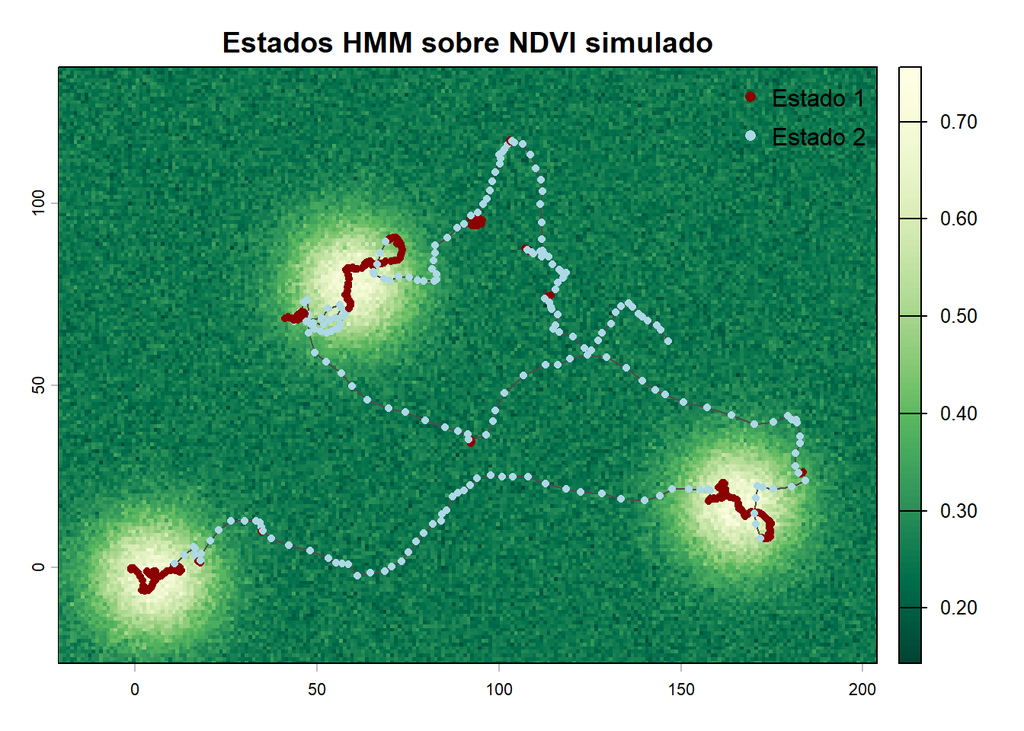

```r
cols <- c("darkred", "lightblue")

plot(r,
     main = "Estados HMM sobre NDVI simulado",
     col = hcl.colors(100, "YlGn"))

lines(df$X, df$Y,
      col = "grey30",
      lwd = 1)

points(df$X, df$Y,
       col = cols[df$state_ndvi],
       pch = 16,
       cex = 0.7)

legend("topright",
       legend = c("Estado 1", "Estado 2"),
       col = cols,
       pch = 16,
       bty = "n")
```

Acá vamos con stationary plot.. es decir ver cómo cambian las probabilidades de transición en función de nuestra covariable. El paquete `momentuHMM` tiene una función para esto.. pero no podemos obtener los valores brutos y el plot es lo que te da y punto, podemos cambiar levemente los colroes y no mucho más.

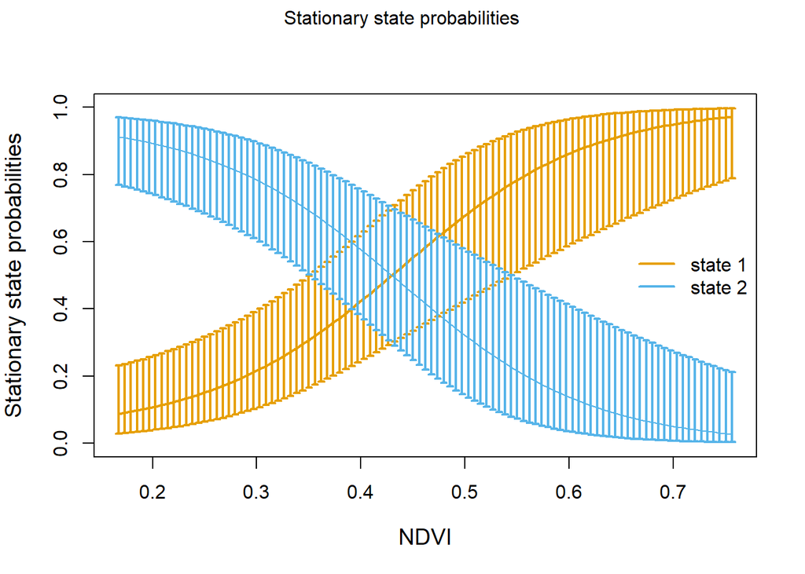

```r
plotStationary(mod_ndvi,
               lwd = 2,
               plotCI = TRUE,
               cex.lab = 1.2,
               cex.axis = 1,
               legend.pos = "right")
```

no es un asco, pero no tenemos los valores crudos para hcaer otras cosas o para modifcar los datos

Acá estamos usando unas funciones que hice para hacer eso.. sacanod los betas recalculamos estas transiciones y las guardamos en una data.frame. Con `source` básicamente ejecutas todo lo que esté en otro script dentro de esta sesión. En el script “stationary2.R” hay tres funciones, una para plotear modelos de 2 estados, otra de 3 estados y otra cosa más que no vamos a usar..

```r
source("functions/stationary2.R")
```

Esta función nos pide el modelo de HMM, la covariable, la data original para tener un rango real de la covariable, solo hace `min(data[[covariate]]) y max(data[[covariate]])`, n_seq que básicamente es los puntosa a lo largo del eje X (filas de la tabla), para la resolución del plot, y finalmente pide el B que son las simulaciones de bootstrap para hacer los intervalos de confianza..

```r
stationary_ndvi <- stationary_2state_covariate(
  model = mod_ndvi,
  covariate = "NDVI",
  data = df,
  n_seq = 200,
  B = 100,
  ci_multiplier = ci)
```

```r
cols <- c("darkred", "royalblue")

plot(stationary_ndvi$NDVI, stationary_ndvi$state1,
     type = "n",
     ylim = c(0, 1),
     xlab = "NDVI",
     ylab = "Probabilidad estacionaria",
     main = "Probabilidad estacionaria según NDVI")

polygon(c(stationary_ndvi$NDVI, rev(stationary_ndvi$NDVI)),
        c(stationary_ndvi$state1_lwr, rev(stationary_ndvi$state1_upr)),
        col = adjustcolor(cols[1], alpha.f = 0.25),
        border = NA)

polygon(c(stationary_ndvi$NDVI, rev(stationary_ndvi$NDVI)),
        c(stationary_ndvi$state2_lwr, rev(stationary_ndvi$state2_upr)),
        col = adjustcolor(cols[2], alpha.f = 0.25),
        border = NA)

lines(stationary_ndvi$NDVI, stationary_ndvi$state1,
      col = cols[1],
      lwd = 5)

lines(stationary_ndvi$NDVI, stationary_ndvi$state2,
      col = cols[2],
      lwd = 5)

legend("right",
       legend = c("Estado 1", "Estado 2"),
       col = cols,
       lwd = 3,
       bty = "n")
```

[figure not shown]

# MoveBank

Vamos a usar un ejemplo de manatíes… si, dice seals.. pero es porque empecé con una df de seals y después vi que tenía una resolución temporal super irregular e iba a ser medio inservible para los HMM. Después me dio fiaca cambiar seals por manatí, lo hice más adelante.

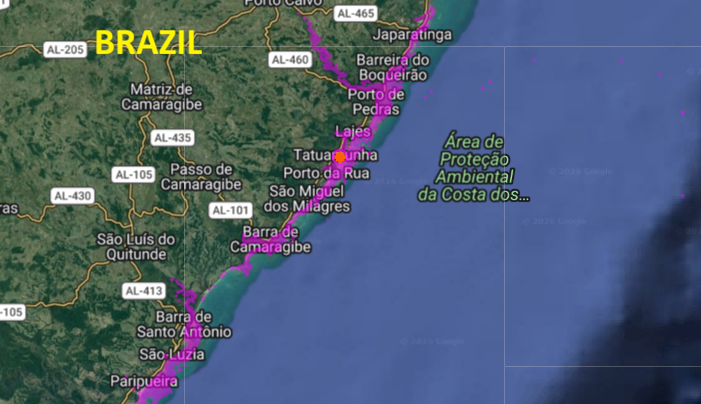

No sé si sirve del todo, pero al menos parece ser regular para probar.

```r
seal <- read.csv("data/tables/manati.csv")
```

```r
str(seal)
```

```
## 'data.frame':    120868 obs. of  10 variables:
##  $ event.id                       : num  2.12e+10 2.12e+10 2.12e+10 2.12e+10 2.12e+10 ...
##  $ visible                        : chr  "true" "true" "true" "true" ...
##  $ timestamp                      : chr  "2012-03-24 15:00:22.000" "2012-03-24 16:00:35.000" "2012-03-24 17:02:22.000" "2012-03-24 18:01:04.000" ...
##  $ location.long                  : num  -35.3 -35.3 -35.3 -35.3 -35.3 ...
##  $ location.lat                   : num  -9.22 -9.22 -9.22 -9.22 -9.21 ...
##  $ sensor.type                    : chr  "gps" "gps" "gps" "gps" ...
##  $ individual.taxon.canonical.name: chr  "Trichechus manatus" "Trichechus manatus" "Trichechus manatus" "Trichechus manatus" ...
##  $ tag.local.identifier           : chr  "97875" "97875" "97875" "97875" ...
##  $ individual.local.identifier    : chr  "Tupa" "Tupa" "Tupa" "Tupa" ...
##  $ study.name                     : chr  "Trichechus manatus Sirenia NE Brazil" "Trichechus manatus Sirenia NE Brazil" "Trichechus manatus Sirenia NE Brazil" "Trichechus manatus Sirenia NE Brazil" ...
```

Cambiamos el formato de tiempo, por el momento no vamos a poner tz correcta. La columna de tiempo la vamos a usar para filtrar datos irregulares nomas.. no me importa si era de día o de noche (podría serlo si fuese una pregunta nuestra), lo que me importa es que la distancia temporal entre las fixes esté bien y para eso el *time zone* no importa

```r
seal$t <- as.POSIXct(seal$timestamp,
                     format = "%Y-%m-%d %H:%M:%S")
```

```r
seal <- seal  |>
  arrange(individual.local.identifier, t) |>
  group_by(individual.local.identifier) |>
  mutate(
    dt = as.numeric(difftime(t, lag(t), units = "mins"))) |>
  dplyr::ungroup()
```

Hasta el tercer cuartil todo parece razonable, pero hay un mega hueco de 3 millones de minutos.. es probable que a un bicho (o varios bichos) lo hayan seguido un año y después lo hayan seguido otro año, o algo así.

```r
summary(seal$dt)
```

```
##      Min.   1st Qu.    Median      Mean   3rd Qu.      Max.      NA's
##       0.0      19.5      31.0     273.8      60.1 3905896.4        38
```

Los HMM toleran bastante bien las irregularidades, pero siempre y cuando no sean descomunales.. vamos a armar “bursts” de trechos relativamente regulares.. en `amt` y `adehabitatLT` existen funciones para esto, pero son bastante perno y te obligan a estar transformando y retransformando objetos.. lo que termina generando muchos desajustes de formato y problemas a futuro.

.

Vamos a hacer burst generosos, que tengan *fix rates* de entre 10 min y 3 horas

```r
seal_30min <- seal |>
  arrange(individual.local.identifier, t) |>
  group_by(individual.local.identifier) |>
  mutate(
    dt = as.numeric(difftime(t, lag(t), units = "mins")),
    regular_step = is.na(dt) | between(dt, 10, 180),
    burst = cumsum(!regular_step)) |>
  filter(regular_step) |>
  ungroup()
```

Se achico bastante la cosa.. pero es posible que tengamos mini trechitos ahí adentro.. vamos a sacar trechos más potables.. con más de 200 localizaciones.

```r
seal_30min <- seal_30min |>
  group_by(individual.local.identifier, burst) |>
  filter(n() >= 200) |>
  ungroup()
```

Veamos quienes son los individuos que sobrevivieron a la filtrada.

```r
unique(seal_30min$individual.local.identifier)
```

```
##  [1] "Assu"         "Branca"       "Clara"        "Diogo"        "Fontinho"
##  [6] "Guga"         "Iemanja"      "Joana"        "Lua"          "Luiz Gonzaga"
## [11] "Romulo"       "Sol"          "Telinha"      "Tita"         "Tuca"
## [16] "Tupa"
```

Resumimos para ver cómo está la cosa

```r
burst_summary <- seal_30min |>
  group_by(individual.local.identifier, burst) |>
  summarise(
    n = n(),
    start = min(t),
    end = max(t),
    .groups = "drop")

burst_summary
```

| individual.local.identifier | burst | n | start | end |
| --- | --- | --- | --- | --- |
| Assu | 369 | 249 | 2014-01-30 12:00:35 | 2014-02-09 21:01:05 |
| Branca | 0 | 245 | 2015-09-29 15:03:05 | 2015-10-10 07:02:55 |
| Clara | 1100 | 386 | 2015-10-27 20:08:29 | 2015-11-13 10:02:35 |
| Clara | 1102 | 204 | 2015-11-13 21:08:16 | 2015-11-22 19:03:35 |
| Clara | 1106 | 901 | 2015-11-26 18:03:02 | 2016-01-04 10:00:35 |
| Diogo | 10 | 392 | 2017-05-02 14:53:28 | 2017-05-13 12:34:08 |
| Fontinho | 335 | 200 | 2013-04-23 13:01:00 | 2013-04-27 17:57:00 |
| Fontinho | 378 | 220 | 2013-06-24 10:02:00 | 2013-06-29 10:31:00 |
| Guga | 1 | 233 | 2011-09-18 08:00:49 | 2011-09-28 04:02:27 |
| Iemanja | 169 | 433 | 2016-12-23 14:02:29 | 2017-01-01 12:42:02 |

[output cut: 58 more lines]

Los mejores bursts.. podríamos guardar todos, pero ahora no nos interesa.

```r
best_bursts <- burst_summary |>
  group_by(individual.local.identifier) |>
  slice_max(n, n = 1, with_ties = FALSE) |>
  ungroup()

best_bursts
```

| individual.local.identifier | burst | n | start | end |
| --- | --- | --- | --- | --- |
| Assu | 369 | 249 | 2014-01-30 12:00:35 | 2014-02-09 21:01:05 |
| Branca | 0 | 245 | 2015-09-29 15:03:05 | 2015-10-10 07:02:55 |
| Clara | 1106 | 901 | 2015-11-26 18:03:02 | 2016-01-04 10:00:35 |
| Diogo | 10 | 392 | 2017-05-02 14:53:28 | 2017-05-13 12:34:08 |
| Fontinho | 378 | 220 | 2013-06-24 10:02:00 | 2013-06-29 10:31:00 |
| Guga | 1 | 233 | 2011-09-18 08:00:49 | 2011-09-28 04:02:27 |
| Iemanja | 169 | 433 | 2016-12-23 14:02:29 | 2017-01-01 12:42:02 |
| Joana | 23 | 335 | 2014-08-28 12:02:53 | 2014-09-04 18:26:31 |
| Lua | 1 | 473 | 2016-11-04 08:02:23 | 2016-11-24 13:59:57 |
| Luiz Gonzaga | 28 | 719 | 2019-11-17 14:06:06 | 2019-12-02 23:33:02 |

[output cut: 6 more lines]

Me quedo con las flas de seal_30min que están en best_burst.

```r
seal_best <- seal_30min |>
  inner_join(
    best_bursts |>
      dplyr::select(individual.local.identifier, burst),
    by = c("individual.local.identifier", "burst"))
```

Bien, tenemos 9184 localizaciones relativamente buenas..

Vamos a cambiar los nombres feos esos.. Aprovechamos y cambiamos foca por manatí..

Remarco que estos cambios de nombre no son puramente estéticos, sino que momentuHMM trabaja con ciertos nombres.. particularmente $ID, x, y$

```r
manati <- seal_best |> dplyr::select(event.id,
                              location.long,
                              location.lat,
                              individual.local.identifier,
                              t,
                              dt,
                              burst) |>
  rename(id = individual.local.identifier,
         lat = location.lat,
         lon = location.long,
         loc = event.id )

manati <- manati |> na.omit()
```

Vemos los manatíes o mantises o mantise o manatís

```r
require(sf)

mana_sf <- st_as_sf(manati,
                    coords = c("lon", "lat"),
                    crs = 4326)

mapview::mapview(mana_sf,
                 zcol = "id",
                 map.type = "Esri.WorldImagery")
```

[interactive chart not shown]

Sin UTM no podfemos hacer nada… Esto simepre es googleable, pero podemos ver la zona con este calculito.

REcuerdo porque estos números.. la tierra va de -180 a 180… al sumarle 180 lo mantengo en lo positivo y entre 0 y 360. UTM parte la tierra en 60 franjas, de 6° cada una.. floor simplemente te da el número entero (se podría sacar).. el +1 se lo sumo porque las zonas van de 1 a 60, no de 0 a 59.

```r
coords <- st_coordinates(mana_sf)

lon <- coords[,1]

zone <- floor((mean(lon) + 180)/6) + 1

zone
```

```
## [1] 25
```

Hemisferios sur, asi que es 327XX

```r
manat_utm <- st_transform(mana_sf, crs=32725)

xy <- st_coordinates(manat_utm)

manati$x <- xy[,1]
manati$y <- xy[,2]
```

#### Preparamos HMM

Es importante ordenar los datos.. acá el tiempo va a dejar de existir así que necesitamos que esten de menor a mayor según tiempo.. podríamos hechar un moco muy grande sino ordenamos.

```r
manati_prep <- manati |>
  arrange(id, burst, t) |>
  mutate(
    ID_hmm = paste(id, burst, sep = "_")) |>
  dplyr::select(
    ID = ID_hmm,
    x,
    y) |>
  as.data.frame()
```

Usamos la función prepData

```r
manati_hmm <- momentuHMM::prepData(
  data = manati_prep,
  type = "UTM",
  coordNames = c("x", "y"))
```

```r
summary(manati_hmm$step)
```

```
##    Min. 1st Qu.  Median    Mean 3rd Qu.    Max.    NA's
##    0.00   13.45   42.96  132.29  135.82 4532.04      16
```

```r
quantile(manati_hmm$step,
         probs = c(0.1, 0.25, 0.5, 0.75, 0.9, 0.95),
         na.rm = TRUE)
```

```
##        10%        25%        50%        75%        90%        95%
##   5.977989  13.449940  42.960266 135.824435 356.837378 577.190562
```

```r
par(mfrow = c(1, 1),
    mar = c(3, 4, 2, 1),
    mgp = c(2, 0.7, 0),
    bg = "#0b0f14",
    col.axis = "white",
    col.lab = "white",
    col.main = "white")

hist(manati_hmm$step,
     breaks = 50,
     col = "grey48",
     border = "grey11",
     main = "Distribución de step length",
     xlab = "Step length",
     ylim = c(0,0.015),
     freq = FALSE,
     axes = FALSE)

lines(density(manati_hmm$step[manati_hmm$step > 0 & !is.na(manati_hmm$step)]),
  col = "darkorange",
  lwd = 2)

axis(1, col = "white", col.axis = "white")
axis(2, col = "white", col.axis = "white")
box(col = "white")
```

[figure not shown]

```r
nbStates <- 2

dist <- list(
  step = "gamma",
  angle = "vm")

step_q <- quantile(manati_hmm$step,
                   probs = c(0.25, 0.75),
                   na.rm = TRUE)

step_sd <- sd(manati_hmm$step, na.rm = TRUE)

zero_prop <- mean(manati_hmm$step == 0, na.rm = TRUE)

Par0 <- list(
  step = c(
    step_q[1], step_q[2],        # medias
    step_sd / 3, step_sd,        # sd
    zero_prop * 1.5, zero_prop   # masa en cero
  ),
  angle = c(
    0.5, 2))

Par0
```

```
## $step
##          25%          75%
##  13.44993962 135.82443489  79.58048913 238.74146739   0.05514947   0.03676631
##
## $angle
## [1] 0.5 2.0
```

**Zero Mass**. Acá vemos algo nuevo, sin esto te va a salir un aviso que faltan parámetros, lo mismo que si intentasemos ajustar 3 estados pero con 2 medias para pasos. El Zero Mass es parte de las exigencias de `momentuHMM` y de su version anterior `moveHMM`. Cuando tenemos una proporción muy grande de ceros (lo podemos chequear con `mean(manati_hmm$step == 0)`), en genrarl mayor al 5–10 %, es necesario que el modelo distinga entre “no moverse” y “moverse muy poquitito”. Las tipicas distribuciones de Gamma o Weibull no aceptan ceros y el modelo termina empujando paramentros para aproximar esos ceros, lo que termina resultando en una peor estimación de los estados.

.

Conceptualmente es similar a los modelos mezcla (ej. inflados en cero): un proceso para los ceros y otro para los “no cero”. matematicamete el modelo termina siendo así

$$P(X = 0 \mid k) = \pi_{0,k}$$

$$P(X > 0 \mid k) = (1 - \pi_{0,k}) \cdot f(x \mid \theta_k)$$

Dónde $\pi_0$ se calcula para cada $k$ como
$$\pi_{0,k} = \frac{1}{1 + e^{-\eta_k}}$$

Donde $\eta_k$ es un parametro libre que tenemos que definir en relación a los ceros.. si hubiese un 30 % de ceros podemos poner 0.6 para el estado estacionarios y 0.1 para el de tránsito.. es algo tentativo y hay que probar, pero si o si debe estar entre 1 y 0 y ser mayor para el estado de menor movilidad.

```r
mod_manati_2 <- fitHMM(
  data = manati_hmm,
  nbStates = nbStates,
  dist = dist,
  Par0 = Par0)
```

```r
mod_manati_2
```

```
## Value of the maximum log-likelihood: -66299.32
##
##
## step parameters:
## ----------------
##              state 1      state 2
## mean     32.23291649 267.87001716
## sd       29.07351140 272.70883126
## zeromass  0.06350305   0.00136056
##
## angle parameters:
## -----------------
##                    state 1   state 2
## mean          0.000000e+00 0.0000000
## concentration 4.863198e-07 0.5997233
##
## Regression coeffs for the transition probabilities:
## ---------------------------------------------------
##                1 -> 2    2 -> 1
## (Intercept) -2.232766 -1.912247
##
## Transition probability matrix:
## ------------------------------
##           state 1    state 2
## state 1 0.9031536 0.09684643
## state 2 0.1287286 0.87127136
##
## Initial distribution:
## ---------------------
##   state 1   state 2
## 0.4176707 0.5823293
```

### Interpretación del HMM

El modelo ajustado separa la trayectoria en dos estados de movimiento, aparentemente bien diferenciados

#### Parámetros de step length

| Estado | Media step | SD step | Masa en cero | Interpretación |
| --- | --- | --- | --- | --- |
| Estado 1 | 32.2 m/h | 29.1 | 0.064 | Movimiento bajo o residencia |
| Estado 2 | 267.9 m/h | 272.7 | 0.001 | Desplazamiento |

El **estado 1** representa movimientos muy cortos, con una proporción apreciable de pasos cero. Esto puede interpretarse como un estado de baja movilidad, residencia, descanso o uso local del espacio.

El **estado 2** representa pasos mucho más largos, con casi ausencia de pasos cero. Este estado es compatible con desplazamiento o tránsito.

#### Parámetros de turning angle

| Estado | Media angular | Concentración | Interpretación |
| --- | --- | --- | --- |
| Estado 1 | 0 | ≈ 0 | Ángulos casi aleatorios |
| Estado 2 | 0 | 0.60 | Mayor persistencia direccional |

La concentración angular cercana a cero en el estado 1 indica que los movimientos no tienen una dirección dominante. En cambio, el estado 2 muestra mayor concentración alrededor de cero, lo que sugiere trayectorias más direccionales.

#### Matriz de transición

La matriz de transición estimada fue:

$$\Gamma = \begin{pmatrix} 0.903 & 0.097
\\ 0.129 & 0.871 \end{pmatrix}$$

Esto indica que ambos estados son persistentes:

- si el manatí está en el estado 1, tiene probabilidad 0.90 de permanecer allí;
- si está en el estado 2, tiene probabilidad 0.87 de permanecer en ese estado.

#### Duración esperada de los estados

La duración esperada se calcula como:

$$E(D_k) = \frac{1}{1 - \gamma_{kk}}$$

Para este modelo:

$$E(D_1) \approx \frac{1}{1 - 0.903} \approx
10.3$$

$$E(D_2) \approx \frac{1}{1 - 0.871} \approx
7.7$$

Como la resolución temporal es aproximadamente horaria, esto sugiere que el manatí permanece en promedio unas 10 horas en el estado de baja movilidad y unas 8 horas en el estado de desplazamiento.

### Interpretación general

El HMM describe una alternancia entre dos modos de movimiento:

- **Estado 1:** pasos cortos, presencia de pasos cero y dirección poco estructurada. Interpretación: residencia, descanso, uso local del espacio o forrajeo restringido.
- **Estado 2:** pasos largos, casi sin pasos cero y mayor persistencia direccional. Interpretación: tránsito o desplazamiento.

En síntesis, el modelo está capturando un contraste entre **baja movilidad local** y **desplazamiento direccional**, con ambos estados mostrando persistencia temporal.

Ejecutamos viterbi para extraer la secuencia más probable de estados para cada locs dados los pararmetros, IC y matrices correspondientes, o al menos estiamados por el forwards.

```r
states_manati_2 <- viterbi(mod_manati_2)
table(states_manati_2)
```

```
## states_manati_2
##    1    2
## 5353 3829
```

Recordemos que states va a ser un simple vector de 1 y 2… esto lo podemos unir a la data.frame original super fácil.. si no tiene el mismo número de filas entonces paso algo raro.. tener esas categrías ahí integradas es super cómodo, ya que podemos emepzar a hacer mil cosas: plotear estatico o en el espacio real, estimar proporciones, ajustar GLMs si quisiesemos o lo que fuere.

```r
manati$state <- states_manati_2
```

Cambiamos nombre

```r
manati$state_label <- factor(
  manati$state,
  levels = c(1, 2),
  labels = c("Baja movilidad", "Desplazamiento")
)
```

```r
manati_sf <- st_as_sf(
  manati,
  coords = c("x", "y"),
  crs = 32725,
  remove = FALSE)

manati_sf_4326 <- st_transform(manati_sf, 4326)
```

Vamos con la tita que tenía buena cantidad de datos

```r
id_plot <- "Tita"

tita_sf <- manati_sf_4326 |>
  filter(id == id_plot) |>
  arrange(t)
```

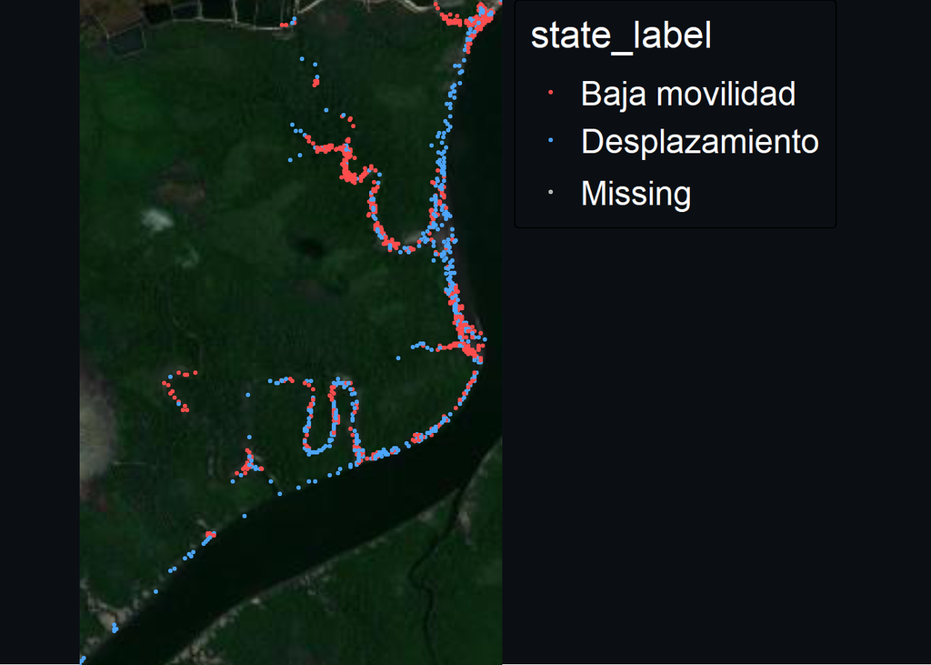

```r
tmap_mode("plot")

par(bg = "#0b0f14")

tm_shape(tita_sf) +
  tm_basemap("Esri.WorldImagery") +
  tm_dots(
    col = "state_label",
    palette = c("#ff4d4d", "#4da6ff"),
    size = 0.2,
    alpha = 0.9,
    border.color="black",
    border.lwd = 0.5) +
  tm_layout(
    bg.color = "#0b0f14",
        outer.bg.color = "#0b0f14",
    outer.margins = 0,
    inner.margins = 0,
    frame = FALSE,
    legend.bg.color = "#0b0f14",
    legend.text.color = "white",
    legend.title.color = "white",
    legend.text.size = 1.5,
    legend.title.size = 1.7)
```

### NDVI

Acá podríamos buscar distitnas variables para estimar las probabilidades estacionarias a partir de las matrices obtenidas en el HMM.

Damos unos pasos para atrás para ajustar solo para un individuo y su propio HMM

Antes de seguir tenemos que generar una variable que podría ser interesante. Vamos con el NDVI, pero también podría ser “cercania al continente”… pero buenon, vamos con una sola por el momento..

### NDVI

Aprovehcamos y vemos como obtener el NDVI desde imagenes satelitales

Hay varias opciones, pero yo suelo usar [Copernicus](https://browser.dataspace.copernicus.eu/), los Sentinel-2 L2A tiene resolucion de 10 metros y buena resolución temporal.. Esto permite ver cambios relativamente finos (para bichos que se mueven suficiente; pasos >10 m) y cambios estacionales. Tita tenía bastante datos pero todos amontonados en un rio o estuario, quizás el NDVI es medio estable.. Vamos a probar con otro, no sé si servirá pero bue.. vamos con Clara.

Hago dos df, la primera solo va a servir para ver cuándo se muestreo a Clara (las de HMM no tienen t)

```r
ind_df <- manati |> dplyr::filter(id == "Clara")

ind_hmm_df <- manati_hmm |> dplyr::filter(ID == "Clara_1106")
```

```r
ind_df |> summarise(min = min(t),
                     max = max(t))
```

| min | max |
| --- | --- |
| 2015-11-26 18:03:02 | 2016-01-04 10:00:35 |

Bueno, desde novimenre a enero maso.. seguro que cambia pero vamos a asumir que no, más facil.

Vamos con una ubicacion intermedia.. usamos la mediana porque la media puede estar muy afectada por puntos raros.. a lo sumo esos quedaran con NA, no pasa nada

```r
lat_med <- median(ind_df$lat, na.rm = TRUE)
lon_med <- median(ind_df$lon, na.rm = TRUE)

lat_med
```

```
## [1] -9.22091
```

```r
lon_med
```

```
## [1] -35.33483
```

bueno ahora vamos con Copernicus, intento ir paso a paso.. una vez en la plataforma indicamos la fecha y las coordenadas

Tuve que elegir una capa muy nueva porque en la plataforma faltan imagenes de esa zona.. con landsat podríamos haber conseguido más pero bueno, vamos con esta para tener una idea de como varia el NDVI entre el estuario y el mar.

[figure not shown]

Metemos la capa y calculamos el NDVI

```r
require(terra)

b8_path <- "data/spatial/S2B_MSIL2A_20180523T124319_N0500_R009_T25LBK_20230704T151643.SAFE/GRANULE/L2A_T25LBK_A006327_20180523T124315/IMG_DATA/R10m/T25LBK_20180523T124319_B08_10m.jp2"

b4_path <- "data/spatial/S2B_MSIL2A_20180523T124319_N0500_R009_T25LBK_20230704T151643.SAFE/GRANULE/L2A_T25LBK_A006327_20180523T124315/IMG_DATA/R10m/T25LBK_20180523T124319_B04_10m.jp2"

b8 <- rast(b8_path)
b4 <- rast(b4_path)

ndvi <- (b8 - b4) / (b8 + b4)
names(ndvi) <- "NDVI"
```

```r
ind_sf_4326 <- st_as_sf(
  ind_df,
  coords = c("lon", "lat"),
  crs = 4326,
  remove = FALSE)
```

Vamos con el CRS

```r
ind_sf_s2 <- st_transform(ind_sf_4326, crs(ndvi))
```

Sacamos el NDVI para cada loc

```r
ndvi_vals <- terra::extract(
  ndvi,
  vect(ind_sf_s2))

ind_df_ndvi <- ind_df %>%
  mutate(NDVI = ndvi_vals$NDVI)
```

Vamos a unir el ndvi a la dataset lista para ajustar el HMM… usamos $x$ e $y$ como criterio de union

```r
ind_df_ndvi_unique <- ind_df_ndvi %>%
  distinct(x, y, .keep_all = TRUE)
```

```r
ind_hmm_df <- ind_hmm_df |>
  left_join(
    ind_df_ndvi_unique |> select(x, y, NDVI),
    by = c("x", "y"))
```

Vimos maaaas o menos cómo se mueven estos manatises así que podemos arriesgar unos valores iniciales razonables.

```r
nbStates <- 2

dist <- list(
  step = "gamma",
  angle = "vm")

zero_prop <- mean(manati_hmm$step == 0, na.rm = TRUE)

Par0 <- list(
  step = c(
    20, 200,
    10, 100),
  angle = c(
    0.5, 2))

Par0
```

```
## $step
## [1]  20 200  10 100
##
## $angle
## [1] 0.5 2.0
```

Ajustamos el modelo

```r
ind_mod <- fitHMM(
  data = ind_hmm_df,
  nbStates = nbStates,
  dist = dist,
  Par0 = Par0,
  formula = ~ NDVI)
```

Resumen de la Clara

```r
ind_mod
```

```
## Value of the maximum log-likelihood: -6559.163
##
##
## step parameters:
## ----------------
##       state 1  state 2
## mean 21.62597 212.2856
## sd   18.68001 196.1497
##
## angle parameters:
## -----------------
##                    state 1   state 2
## mean          0.000000e+00 0.0000000
## concentration 3.427644e-11 0.8322178
##
## Regression coeffs for the transition probabilities:
## ---------------------------------------------------
##                1 -> 2     2 -> 1
## (Intercept) -1.049467 -1.5307961
## NDVI        -2.744223  0.1502619
##
## Transition probability matrix (based on mean covariate values):
## ---------------------------------------------------------------
##           state 1   state 2
## state 1 0.8099819 0.1900181
## state 2 0.1811062 0.8188938
##
## Initial distribution:
## ---------------------
##  state 1  state 2
## 0.529087 0.470913
```

Viterbi para extraer los parametros

```r
states_ind <- viterbi(ind_mod)
table(states_ind)
```

```
## states_ind
##   1   2
## 444 457
```

Re parejito

```r
ind_df_ndvi$state_ndvi <- states_ind
```

Cargamos de nuevo las funciones, solo para mostrar.

```r
source("functions/stationary2.R")
```

```r
stationary_ndvi <- stationary_2state_covariate(
  model = ind_mod,
  covariate = "NDVI",
  data = df,
  n_seq = 200,
  B = 100,
  ci_multiplier = ci)
```

Nota: es probable que este cargando paquetes varias veces innecesariamente. No hace falta, lo hago porque esta medio largo el script y me voy olvidando que puse..

```r
require(ggplot2); require(tidyr)

cols <- c("Estado 1" = "darkred",
          "Estado 2" = "royalblue")

stationary_long <- bind_rows(
  stationary_ndvi |>
    transmute(
      NDVI = NDVI,
      Estado = "Estado 1",
      prob = state1,
      lwr = state1_lwr,
      upr = state1_upr),
  stationary_ndvi |>
    transmute(
      NDVI = NDVI,
      Estado = "Estado 2",
      prob = state2,
      lwr = state2_lwr,
      upr = state2_upr))

ggplot(stationary_long,
       aes(x = NDVI, y = prob, color = Estado, fill = Estado)) +
  geom_ribbon(
    aes(ymin = lwr, ymax = upr),
    alpha = 0.22,
    show.legend = FALSE,
    color = NA) +
  geom_line(linewidth = 2.5) +
  scale_color_manual(values = cols) +
  scale_fill_manual(values = cols) +
  scale_y_continuous(
    limits = c(0, 1),
    breaks = seq(0, 1, 0.2),
    expand = expansion(mult = c(0, 0.02))) +
  scale_x_continuous(
  breaks = seq(
    floor(min(stationary_long$NDVI, na.rm = TRUE) * 10) / 10,
    ceiling(max(stationary_long$NDVI, na.rm = TRUE) * 10) / 10,
    by = 0.1),
  expand = expansion(mult = c(0.01, 0.01))) +
  labs(
    x = "NDVI",
    y = "Probabilidad estacionaria",
    color = NULL) +
  guides(
    color = guide_legend(
      override.aes = list(linewidth = 2.5)),
    fill = guide_legend(
      override.aes = list(alpha = 0.22, color = NA)))  +
  theme_classic(base_size = 14) +
  theme(
    legend.position = c(0.82, 0.5),
    legend.background = element_blank(),
    legend.key = element_blank(),
    legend.text = element_text(size = 14),
    legend.key.spacing.y = unit(0.3, "cm"),

    axis.title.x = element_text(size = 14,
    margin = margin(t = 10)),
  axis.title.y = element_text(size = 14,
    margin = margin(r = 10)),
    axis.text = element_text(size = 12, color = "black"),
    axis.line = element_line(linewidth = 0.6, color = "black"),
    axis.ticks = element_line(linewidth = 0.5, color = "black"),

    plot.margin = margin(17, 17, 17, 17))
```

[figure not shown]

```r
library(terra)
ind_sf_s2$state_ndvi <- states_ind

buffer <- 500
ext_ind <- ext(ind_sf_s2)

ext_zoom <- ext(
  ext_ind$xmin - buffer,
  ext_ind$xmax + buffer,
  ext_ind$ymin - buffer,
  ext_ind$ymax + buffer)
```

```r
ndvi_zoom <- crop(ndvi, ext_zoom)
```

```r
cols <- c("firebrick", "steelblue1")

ind_sf_s2$state_ndvi <- factor(ind_sf_s2$state_ndvi)

plot(ndvi_zoom, main = "NDVI (zoom)")

plot(
  st_geometry(ind_sf_s2),
  col = "black",
  bg = cols[ind_sf_s2$state_ndvi],
  pch = 21,
  cex = 1,
  add = TRUE)

legend(
  "topright",
  legend = levels(ind_sf_s2$state_ndvi),
  col = cols,
  pch = 20,
  title = "state_ndvi")
```

[figure not shown]

```r
library(patchwork)

ndvi_df <- as.data.frame(ndvi_zoom, xy = TRUE, na.rm = TRUE)

names(ndvi_df)[3] <- "NDVI"


ind_sf_s2$state_ndvi <- factor(ind_sf_s2$state_ndvi)

cols <- c("firebrick", "steelblue1")

base_theme <- theme_bw() +
  theme(
    panel.grid = element_blank(),

    plot.title = element_text(size = 14, face = "bold", hjust = 0.5),

    axis.title = element_text(size = 11),
    axis.text = element_text(size = 9),
    axis.text.x = element_text(angle = 30, hjust = 1),

    legend.title = element_text(size = 10),
    legend.text = element_text(size = 9),
    legend.key.width = unit(1.2, "cm"),
    legend.key.height = unit(0.7, "cm"))

scale_ndvi <- scale_fill_viridis_c(
  name = "NDVI",
  limits = range(ndvi_df$NDVI, na.rm = TRUE),
  guide = guide_colorbar(
    direction = "vertical",
    barheight = unit(6, "cm"),
    barwidth  = unit(0.8, "cm")))

p1 <- ggplot() +
  geom_raster(
    data = ndvi_df,
    aes(x = x, y = y, fill = NDVI)
  ) +
  coord_sf(expand = FALSE) +
  scale_ndvi +
  base_theme

p2 <- ggplot() +
  geom_raster(
    data = ndvi_df,
    aes(x = x, y = y, fill = NDVI),
    show.legend = FALSE
  ) +
  scale_fill_viridis_c(
    name = "NDVI",
    limits = range(ndvi_df$NDVI, na.rm = TRUE),
    guide = "none"
  ) +

  ggnewscale::new_scale_fill() +

  geom_sf(
    data = ind_sf_s2,
    aes(fill = state_ndvi),
    color = "black",
    shape = 21,
    size = 2.2,
    stroke = 0.6,
    show.legend = TRUE) +
  scale_fill_manual(
    name = "Estado HMM",
    values = cols,
    guide = guide_legend(
    override.aes = list(
      size = 3))) +
  coord_sf(expand = FALSE) +
  theme_void() +
  theme(
  legend.key.size = unit(1, "cm"))



(p1 + p2) +
  plot_layout(guides = "collect") &
  theme(
    legend.position = "right",
    legend.box = "vertical"  )
```

[figure not shown]